# Testing Times

### Overview

**Context**

In the Fall of 2017 semester at BYUI, 150 students took an exam in Math 221A in the testing center. The exam was open for about 88 hours. The students chose when to take the exam when it was convienent for their schedule.

**The Study**

It is possible that the more prepared a student is for an exam, the sooner they take that exam. To test to see if that is true, I will check to see if there is a relationship between when the students chose to take the test and the score they achieved on the test?

** The Data **

```r
MTATests <- read.csv("../Data/MapleTAdata4.csv",header=TRUE, stringsAsFactors = FALSE)

datatable(MTATests, extensions = "Responsive",options=list(lengthMenu = c(5,10,20)))
```

|  | When | Score | Percent |
| --- | --- | --- | --- |
| 1 | 49.93333333 | 36 | 0.947368421 |
| 2 | 76.73333333 | 23 | 0.605263158 |
| 3 | 76.13333333 | 33 | 0.868421053 |
| 4 | 22.9 | 31 | 0.815789474 |
| 5 | 47.38333333 | 33 | 0.868421053 |
| 6 | 78.83333333 | 37 | 0.973684211 |
| 7 | 76.26666667 | 30 | 0.789473684 |
| 8 | 58.33333333 | 23 | 0.605263158 |
| 9 | 25.53333333 | 33 | 0.868421053 |
| 10 | 48.23333333 | 38 | 1 |

[output cut: 140 more lines]

### To Critiquers

Dear Critiquer,

You may notice that the assumptions to perform linear regression are not met. However, you could judge me on other things:

- Getting the dataset .csv file into R
- Formatting the dataset
- Analyzing the test
- My interpretation

### Analysis

The scatterplot of the tests shows that there is a negative trend in the exams; the longer the students wait to take the exam the lower the expected score on that exam.

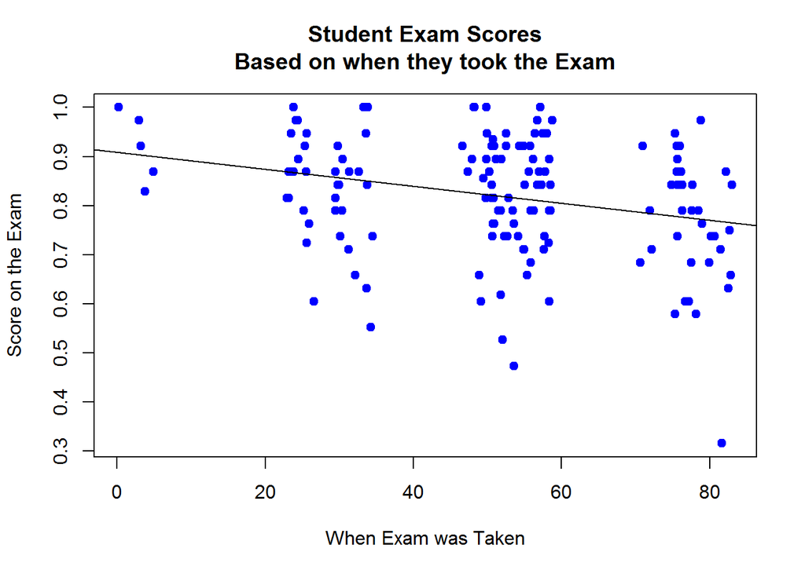

```r
plot(Percent ~ When, data=MTATests, xlab="When Exam was Taken", ylab="Score on the Exam", col="blue", pch=19, main="Student Exam Scores\nBased on when they took the Exam")
MTA.lm <- lm(Percent ~ When, data=MTATests)
slopep <- summary(MTA.lm)$coefficients[2,4]
abline(MTA.lm)
```

#### Inference

We run a linear regression analysis to see if there is a relationship between when a student takes the exam and their score on the exam. $\beta_1$ is the slope of the regression line.

#### Hypotheses

$${ H }_{ 0 }: \beta_1 =0 \text{ (there is no relationship between when a student takes an exam and what score they get on that exam)} \\ { H }_{ a }: \beta_1 \neq0 \text{ (there is a relationship between when a student takes an exam and what score they get on that exam)}$$

```r
pander(summary(MTA.lm))
```

|  | Estimate | Std. Error | t value | Pr(>\|t\|) |
| --- | --- | --- | --- | --- |
| **(Intercept)** | 0.909 | 0.02675 | 33.99 | 8.605e-72 |
| **When** | -0.001733 | 0.0004877 | -3.553 | 0.0005107 |

Fitting linear model: Percent ~ When

| Observations | Residual Std. Error | $R^2$ | Adjusted $R^2$ |
| --- | --- | --- | --- |
| 150 | 0.1174 | 0.07861 | 0.07238 |

With a p-value for slope of **0.000511** and a level of significance of **$\alpha=.05$**, the inference tells us that there is likely and negative relationship between when a student takes a test and what score they get on the test.

### Assumptions

1. **Linear Relation**: the regression relation between $Y$ and $X$ is linear.
2. **Normal Errors**: the error terms are ** almost ** normally distributed with a mean of zero.
3. **Constant Variance**: the variance of the error terms is constant over all $X$ values.
4. **Fixed X**: the $X$ values can be considered fixed and measured without error.
5. **Independent Errors**: the error terms are independent.

[figure not shown]

```r
plot(MTA.lm, which=1:1, caption="The error terms seem to decrease with increasing values of X")
```

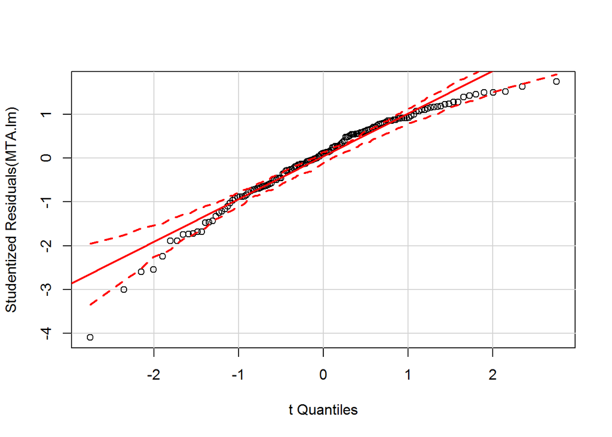

```r
qqPlot(MTA.lm)
```

**The distribution of error terms is a little skewed.**

### Interpretation

```r
yint<-summary(MTA.lm)$coefficients[1,1]
slope<-summary(MTA.lm)$coefficients[2,1]
```

Even though not all of the assumptions were met to perform this inference, there is a clear negative ralationship between when a student takes an exam and their performance on that exam.

There is an influatial point in the data where a student took the test late and scored quite low. This data point contributes to the strength of the negative relationship.

If this inference is to be believed, the slope of the regression is -0.001733. Which means, we would expect that for every day (24 hours) in delay, the average score would change about -4.1593016%.

Also, a for students that take the test when it opens, we would expect a score of 90.8993193%.